# cooking

This assignment provided a list of cusine with the ingredients and asks to predict which country a recipe is from, given a list of its ingredient. In the dataset, it includes the recipe id, the type of cuisine, and the list of ingredients of each recipe.

The data is stored in JSON format and here is the snippet.

{ "id": 24717, "cuisine": "indian", "ingredients": [ "tumeric", "vegetable stock", "tomatoes", "garam masala", "naan", "red lentils", "red chili peppers", "onions", "spinach", "sweet potatoes" ] }

```python
import pandas as pd
```

```python
import numpy as np
```

```python
import matplotlib.pyplot as plt
```

```python
from collections import Counter
```

```python
%matplotlib inline
```

```python
plt.style.use('ggplot')
```

Before processing the data visualisation is done below in order using math plot.

```python
df_train = pd.read_json('train.json')
df_train.head(7)
```

|  | cuisine | id | ingredients |
| --- | --- | --- | --- |
| 0 | greek | 10259 | [romaine lettuce, black olives, grape tomatoes... |
| 1 | southern_us | 25693 | [plain flour, ground pepper, salt, tomatoes, g... |
| 2 | filipino | 20130 | [eggs, pepper, salt, mayonaise, cooking oil, g... |
| 3 | indian | 22213 | [water, vegetable oil, wheat, salt] |
| 4 | indian | 13162 | [black pepper, shallots, cornflour, cayenne pe... |
| 5 | jamaican | 6602 | [plain flour, sugar, butter, eggs, fresh ginge... |
| 6 | spanish | 42779 | [olive oil, salt, medium shrimp, pepper, garli... |

Now we will plot a graph to see how many ingredients and cuisines are available in the data set.

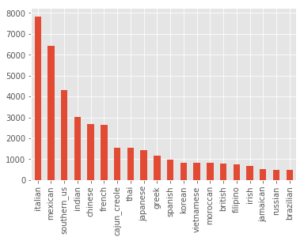

```python
df_train['cuisine'].value_counts().plot(kind='bar')
```

Italian and Mexican have the largest number of recipes and brazilian have least. So, it may influence the training and output.There are few ingredient which are duplicate like "Salt", "Eggs", "Tomatoes" etc.. So, we need to find out the unique ingredients in order to predict the correct cuisine.

# Training with logistic regression classifier

We will use sci kit to perform classification. To do this, we first create a new column in our dataframe by simply concatening the ingredients to a single string. Mainly we need to check wheter or not an ingredient is avaliable in given cuisine. It can be done using CountVectorizer.

```python
df_train['all_ingredients'] = df_train['ingredients'].map(";".join)
df_train.head()
```

|  | cuisine | id | ingredients | all_ingredients |
| --- | --- | --- | --- | --- |
| 0 | greek | 10259 | [romaine lettuce, black olives, grape tomatoes... | romaine lettuce;black olives;grape tomatoes;ga... |
| 1 | southern_us | 25693 | [plain flour, ground pepper, salt, tomatoes, g... | plain flour;ground pepper;salt;tomatoes;ground... |
| 2 | filipino | 20130 | [eggs, pepper, salt, mayonaise, cooking oil, g... | eggs;pepper;salt;mayonaise;cooking oil;green c... |
| 3 | indian | 22213 | [water, vegetable oil, wheat, salt] | water;vegetable oil;wheat;salt |
| 4 | indian | 13162 | [black pepper, shallots, cornflour, cayenne pe... | black pepper;shallots;cornflour;cayenne pepper... |

```python
from sklearn.feature_extraction.text import CountVectorizer
cv = CountVectorizer()
X = cv.fit_transform(df_train['all_ingredients'].values)
X.shape
print(list(cv.vocabulary_.keys())[:100])
```

[output not shown]

```python
from sklearn.preprocessing import LabelEncoder
```

```python
lenc = LabelEncoder()
```

```python
y = lenc.fit_transform(df_train.cuisine)
```

```python
y[:100]
```

```
array([ 6, 16,  4,  7,  7, 10, 17,  9, 13,  9,  9,  3,  9, 13,  9,  7,  1,
        9, 18, 19, 18, 13, 16,  3,  9,  3,  2,  9,  3, 13,  9,  2, 13, 18,
        9,  2,  9,  4, 16, 16,  9,  0, 13,  7, 13,  3,  5, 16, 16, 16, 11,
       16,  9, 16,  9, 10, 11,  7,  9,  8, 18, 18,  7, 10,  9, 18, 12,  5,
        5, 16, 17,  7, 14,  9,  9, 14, 14, 19, 11, 13,  2, 16,  5,  7,  7,
        9,  9,  7, 12, 17,  9, 16, 16,  6, 13, 13, 16,  7,  9,  9])
```

"y" is now a vector with number instead of strings for each cuisine.

```python
lenc.classes_
```

```
array(['brazilian', 'british', 'cajun_creole', 'chinese', 'filipino',
       'french', 'greek', 'indian', 'irish', 'italian', 'jamaican',
       'japanese', 'korean', 'mexican', 'moroccan', 'russian',
       'southern_us', 'spanish', 'thai', 'vietnamese'], dtype=object)
```

```python
from sklearn.cross_validation import train_test_split
```

```python
X_train, X_test, y_train, y_test = train_test_split(X, y, test_size=0.2)
```

```python
from sklearn.linear_model import LogisticRegression
```

```python
logistic = LogisticRegression()
trained_model = logistic.fit(X_train, y_train)
predictions = trained_model.predict(X_test)
print (predictions)
```

```
[16 16 13 ..., 14  2  2]
```

```python
logistic.score(X_test, y_test)
```

```
0.78768070395977374
```